## DS Pipeline - Impact of Socioeconomic Characteristics on COVID in Maryland Counties

# Introduction

### What are socioeconomic characteristics?

Socioeconomic characteristics of a particular region refers to the economic and social factors of the population living in that region. In our case, we are observing the socioeconomic characteristics of Maryland counties, so we will be observing economic and social features of the population living in that county such as age, employment rates, population count, transportation methods, household income, race, education, etc.

### Why do we care about socioeconomic characteristics and its impact on COVID?

In this tutorial, we will also observe the infrastructure of each individual county in Maryland such as transportation and education expenditures. From the data, we will observe if there exists any relationship between socioeconomic factors and the infrastructure built into each county. From there, we will hypothesize whether there's a connection between a county's socieconomic factors and infrastructure with the total number of COVID cases for each county.

Over the past year and a half of the COVID pandemic, we've heard news about how poorer communities and black communities have been disproportionately affected by the pandemic. In this tutorial, we want to analyze the correlation between these socioeconomic factors and determine whether they have any relationship with the number of COVID cases that occur within the county or if there's an external factor influencing the numbers. County infrastructures will also be analyzed to see if they could be a causing factor for the rise of COVID numbers in certain counties.

The tutorial will determine whether there are socioeconomic/infrastructure factors that causes a higher ratio of infected people in a county. The result from this will be useful for policymaking in Maryland to reduce the number of affected individuals of COVID by identifying a correlating or causing factor and implementing policy to make changes. Additionally, it's a good predictor for future health pandemics on which counties are more at risk than others so that authorities can respond better to a future pandemic. Anyone who's looking to move into Maryland could also read this tutorial and make decisions on which county they want to live in to best reduce their risk of getting COVID.

### Data Collection

Fortuntely for us, the data we want for analyzing the demographic information of Maryland counties and socioeconomic status can be found on the public U.S. Government open data website. There will be no data scapping necessary We will be importing seven datasets from the database to observe different county infrastructures and socioeconomic factors over the past few years. COVID numbers from different counties will also be imported up to the lastest date of May 13th 2021. All the datasets are imported as a csv file and we will be using pandas framework to read all of them.

The first dataset we will import are the COVID numbers for each county up to May 13th, 2021. For each county, we considering both the latest number of cases in the county as well as cases over time in the county to observe the rate of rising cases in the county.

The next dataset we'll import is the socioecocnomic characteristics of each county. The characteristics include race, population, employment, age, education levels, housing units, and transportation preferences.

The remaining datasets will be information regarding the infrastruture of the couny such as education level retentions, quality of life, transportation, workforce infrastructure, and education expenditure.

##### Importing the Libraries

```python
import pandas as pd
import numpy as np
from matplotlib import pyplot as plt
from sklearn.linear_model import LinearRegression
```

```python
# Importing all the datasets
spending_table = pd.read_csv('./data/County_Board_of_Education_-_Spending_Disclosures.csv')
workforce_table = pd.read_csv('./data/Choose_Maryland___Compare_Counties_-_Workforce.csv')
quality_table = pd.read_csv('./data/Choose_Maryland___Compare_Counties_-_Quality_Of_Life.csv')
transportation_table = pd.read_csv('./data/Choose_Maryland___Compare_Counties_-_Transportation.csv')
education_table = pd.read_csv('./data/Choose_Maryland___Compare_Counties_-_Education.csv')

covid_table = pd.read_csv('./data/MD_COVID-19_-_Cases_by_County.csv')
socio_table = pd.read_csv('./data/Maryland_Counties_Socioeconomic_Characteristics.csv')
```

```python
socio_table.head()
```

|  | Jurisdictions | Total Households | Population 25 years and older | Less than 9th Grade | High School no Diploma | High School Diploma | Some College no degree | Associates degree | Bachelor's degree | Graduate or Professional | ... | Male | Female | White Alone | Black Alone | Asian Alone | American Indian/Alaska Native Alone | Native Hawaiian/Pacific Islander Alone | Some Other Race Alone | Two or More Races | Hispanic or Latino (of any race) |
| --- | --- | --- | --- | --- | --- | --- | --- | --- | --- | --- | --- | --- | --- | --- | --- | --- | --- | --- | --- | --- | --- |
| 0 | Allegany County | 27759 | 50489 | 1307 | 4002 | 21070 | 10154 | 4758 | 4888 | 4310 | ... | 37892 | 34699 | 64164 | 5899 | 594 | 120 | 24 | 210 | 1580 | 1257 |
| 1 | Anne Arundel County | 205395 | 387306 | 9133 | 21910 | 93676 | 77911 | 29279 | 90536 | 64861 | ... | 279581 | 285019 | 417111 | 91567 | 20818 | 1025 | 408 | 13095 | 20576 | 41275 |
| 2 | Baltimore County | 312859 | 573263 | 18315 | 32698 | 152622 | 112480 | 40355 | 125363 | 91430 | ... | 392930 | 435707 | 514340 | 231516 | 49045 | 2320 | 398 | 8728 | 22290 | 42438 |
| 3 | Calvert County | 31462 | 61269 | 1096 | 2716 | 18833 | 15552 | 4642 | 10564 | 7866 | ... | 45184 | 45640 | 73885 | 10797 | 1504 | 150 | 34 | 541 | 3913 | 3276 |
| 4 | Caroline County | 11996 | 22216 | 1230 | 2470 | 9079 | 4072 | 1687 | 2182 | 1496 | ... | 15971 | 16814 | 26338 | 4376 | 190 | 96 | 18 | 721 | 1046 | 2247 |

5 rows × 41 columns

### Data Processing/Cleaning

The next step in the pipeline is to tidy the data into a format that's readable, simple, and useful for us to begin analysis. We want to group all the data on the county infrastructure and socioeconomic factors into one table for simplicity apart from the education expenditure over time. We won't be analyzing every socioeconomic factor against COVID cases since there are too many factors to make the analysis useful for hypothesis testing. Rather, we want to group up socioeconomic factors with county infrastructure data and then compare them against COVID cases by table for better data management and because some columns correlate/depend on another column of data.

For example, we will group up education levels, education attainment, population levels, number of schools, teacher to student ratio, and school expenditure together as a group and analyze it as a single socioeconomic characteristics. We will analyze the following groups of socioeconomic characteristics: education, employment, population, and transportation.

We will tidy our data even more after we separate each column into their data table and begin our data analysis. It's useful to go back and clean up our data when we find excessive/unnecessary data in our exploratory data analysis step, so it's fine that we don't completely filter out all the unnecessary columns in the next step.

##### Choosing, Grouping, and Sorting data

In the following code, we will group all the infrastructure/socioeconomic data into one table for manageable data. We will also drop columns that we don't need from the tables. We'll also sort our counties by alphabetical order to match with with order of the covid dataset.

```python
# Dropping Columns
spending_table.drop(labels=["Payee Name", "Payee Zip", "Purpose of Payment (Baltimore County only)", 'MBE'],axis=1, inplace=True)
```

```python
socio_table.rename(columns={'Jurisdictions':'County'}, inplace=True)
raw_data = socio_table.merge(workforce_table, on='County', how='left') \
                        .merge(transportation_table, on='County', how='left') \
                        .merge(quality_table, on='County', how='left') \
                        .merge(education_table, on='County', how='left')

raw_data.sort_values(by='County', axis=0,inplace=True)
for i, row in raw_data.iterrows():
    county = row['County'].split()
    if county[-1] == 'County': # this is to avoid removing the name for baltimore city and have two baltimores
        raw_data.loc[i, 'County'] = " ".join(county[:-1])
```

```python
raw_data.head()
```

|  | County | Total Households | Population 25 years and older | Less than 9th Grade | High School no Diploma | High School Diploma | Some College no degree | Associates degree | Bachelor's degree | Graduate or Professional | ... | Number of Housing Units Sold | Annual Number of Public High School Graduates | Public School Student-Teacher Ratio | Public School Expenditures Per Pupil ($ Dollars) | Bachelor's Degree Attainment (%) | High School Attainment (%) | Number of 2-Year Colleges | Number of 4-Year Colleges and Universities | 2-Year College Enrollment | 4-Year College/University Enrollment |
| --- | --- | --- | --- | --- | --- | --- | --- | --- | --- | --- | --- | --- | --- | --- | --- | --- | --- | --- | --- | --- | --- |
| 0 | Allegany | 27759 | 50489 | 1307 | 4002 | 21070 | 10154 | 4758 | 4888 | 4310 | ... | 624 | 642 | 13.9 | 13771 | 18.3 | 90 | 1 | 1 | 2586 | 4831 |
| 1 | Anne Arundel | 205395 | 387306 | 9133 | 21910 | 93676 | 77911 | 29279 | 90536 | 64861 | ... | 8619 | 5268 | 14.7 | 13648 | 40.9 | 92.1 | 1 | 2 | 12655 | 548 |
| 23 | Baltimore City | 239791 | 425235 | 20732 | 46577 | 126395 | 82107 | 20061 | 67779 | 61584 | ... | 8450 | 4108 | 16.1 | 15376 | 31.2 | 84.9 | 1 | 11 | 4909 | 59254 |
| 2 | Baltimore | 312859 | 573263 | 18315 | 32698 | 152622 | 112480 | 40355 | 125363 | 91430 | ... | 9986 | 7171 | 15.1 | 13880 | 38.6 | 91.1 | 1 | 7 | 17732 | 42571 |
| 3 | Calvert | 31462 | 61269 | 1096 | 2716 | 18833 | 15552 | 4642 | 10564 | 7866 | ... | 1576 | 1227 | 15.7 | 14062 | 31.1 | 93.9 | 0 | 0 | NaN | NaN |

5 rows × 72 columns

#### Missing Data

For any missing values, there are two ways to deal with it; we could either drop the column or imputate the data. Due to our abundance of data for each county and the lack of counties in Maryland, we will drop any columns that have too much missing values.

We don't want to impute the data in this case because we don't have many counties to work with and we can't impute the data with median, mode, or mean counties are categorical data and we can't order categorical data. Also, if we were to use the population of a county or number of COVID cases in a county as a way to order the missing data column, we would need to assume there exists some sort of relationship between that column with the missing data column which we cannot make. We have more than enough data about each county such that dropping some columns with missing data is not detrimental to our data analysis while imputation is impossible. Therefore if there are columns with missing data we will drop that column.

We will go through each column and sum the number of `NaN` for each of them.

```python
missing_data = pd.DataFrame(raw_data.isna().sum(), columns=['Missing Count'])
missing_data[missing_data['Missing Count'] != 0]
```

|  | Missing Count |
| --- | --- |
| 2-Year College Enrollment | 8 |
| 4-Year College/University Enrollment | 11 |

We see that we have a lot of missing data for columns in 2-year college enrollment and 4-year colege enrollment. As explained before, these columns will not be used for analyze in our next step in the pipeline. Luckily, most of the other data have no missing values and we still have an abundance of data to analyze for each county.

```python
raw_data.drop(labels=['2-Year College Enrollment', '4-Year College/University Enrollment'], axis=1, inplace=True)
```

##### Missing Data in Covid Table

For `NaN` values in the table with COVID data for each county, we will set missing values as 0 since missing data on COVID cases means that no COVID cases has been detected in that county. We'll also drop the objectid and Unknown column since there's no useful data in either of them.

```python
covid_table.fillna(0, axis=1, inplace=True)
covid_table.drop(labels=['OBJECTID', 'Unknown'], axis=1, inplace=True)
```

##### Creating Socioeconomic characteristics

```python
# socioeconomic characteristics: education, employment, population, transportation
education = raw_data[['County','Less than 9th Grade', 'High School no Diploma', 'High School Diploma',
       'Some College no degree', 'Associates degree', 'Bachelor\'s degree',
       'Graduate or Professional','Annual Number of Public High School Graduates',
       'Public School Student-Teacher Ratio',
       'Public School Expenditures Per Pupil ($ Dollars)',
       'Bachelor\'s Degree Attainment (%)', 'High School Attainment (%)',
       'Number of 2-Year Colleges',
       'Number of 4-Year Colleges and Universities']]
population = raw_data[['County','Total Households', 'Population 25 years and older', 'Median Household Income ($)', 'Families',
       'Percent Families in Poverty',
       'Percent Civilian Population w/ Health Ins. Cov.',
       'Total Housing Units', 'Percent Occupied', 'Percent Vacant',
       'Total Population', 'Voting Age Population', 'Male', 'Female', 'White Alone', 'Black Alone', 'Asian Alone',
       'American Indian/Alaska Native Alone',
       'Native Hawaiian/Pacific Islander Alone', 'Some Other Race Alone',
       'Two or More Races', 'Hispanic or Latino (of any race)', 'Cost of Living Index', 'Average Sale Price of a Home ($ Dollars)',
       'Median Sale Price of a Home ($ Dollars)',
       'Number of Housing Units Sold', ]]
employment = raw_data[['County','Employment Status of the Population 16 years and over',
       'Civilian Labor Force (16 years & over)', 'Employed', 'Unemployed',
       'Unemployment Rate', 'Labor Force',
       'Employment (by place of residence)', 'Unemployment',
       'Unemployment Rate (%)', 'Labor Force Participation Rate, Total (%)',
       'Average Annual Employment (by place of work)',
       'Average Weekly Wage, Total ($ Dollars)',
       'Number of Business Establishments',
       'Number of Business Establishments with 100 or More Workers','Residents Who Work in Own County',
       'Percentage of Employed Residents Who Work in Own County (%)',
       'Percentage of County Jobs Held by Residents (%)',
       'Percentage of County Jobs Held by Non-Residents (%)', ]]
transportation = raw_data[['County','Commute Workers 16 yrs and over',
       'Percent Drove Alone', 'Percent Carpooled',
       'Percent Public Transportation', 'Percent Walked', 'Percent Other',
       'Percent Worked at Home', 'Average Travel Time to Work (Minutes)',
       'Workers Commuting Into the County',
       'Workers Commuting Out of the County',
       'Net Workers Commuting Into/Out of the County']]
```

##### Dates

Lastly, we'll clean up the date column in the covid data to prepare for analysis on cases over time for each county. The time data in the column are in the format of date and time and we want a numerical representation of time, so we will represent our dates as the number of days it's past March 3rd, 2020 since that's the earliest time in our dataset. However, it's hard to represent that without mapping each month to a set number of days for each year. Luckily, we see that the rows of data is recorded each day at 10am, so we can simply create a list from 0 to number of rows of data since the data is uniformly recorded. We'll drop the date column since it's no longer needed.

```python
covid_table['Days from March 3rd, 2020'] = range(covid_table.shape[0])
covid_table.drop(labels=['DATE'],axis=1,inplace=True)
```

### Exploratory Data Analysis (EDA)

We will begin our analyze in this step and formulate our null hyppothesis. This step is dedicated to finding patterns between the data of interest and making a hypothesis about the relationship of the data we have. We would like to see if there are any socioeconomic characteristics or infrastructures that correlate to the growth of COVID cases over time apart from total human population. We consider total human population in an area to be a given socioeconomic characteristic that would affect the number of COVID cases, so we have to manipulate our data so that when we observe an independent variable we don't introduce an external factor that affects the variable.

Our null hypothesis would be:

> H_0 : There are no socioeconomic characteristics nor infrastructures that correlate to the number of COVID cases other than human population.

And our alternative hypothesis:

> H_1 : There is some socioeconomic characteristic or infrastructure that correlates to the number of COVID cases other than human population.

We'll be exploring each table at a time against the number of COVID cases.

Let's first explore the rate of COVID cases in each county and get a sense of how fast the cases grow against time.

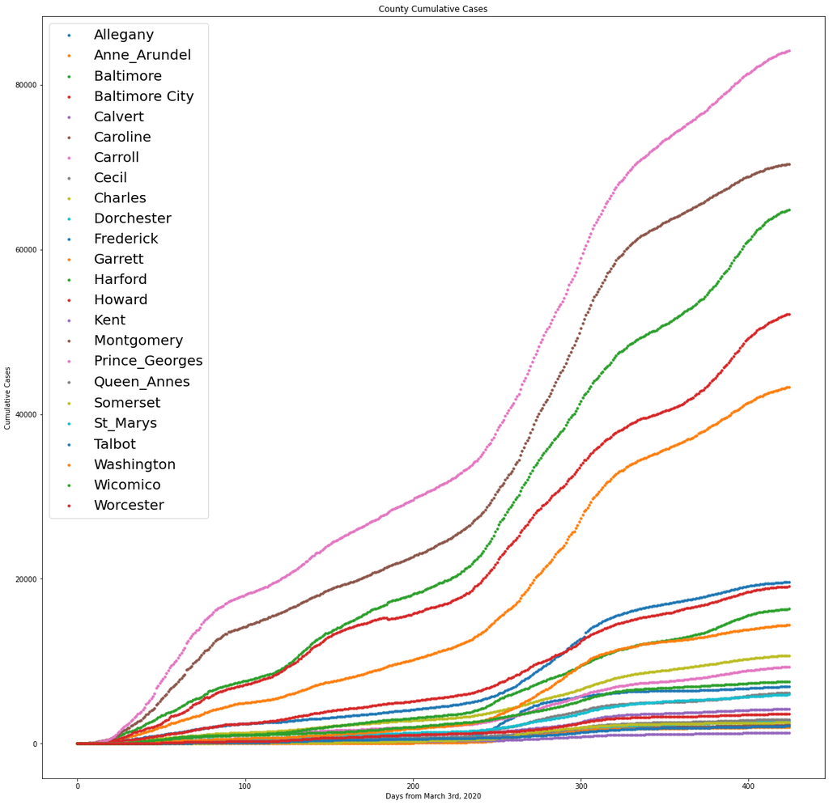

```python
counties = covid_table.columns.values[:-1]
fig = plt.figure(figsize=(20,20))
plt.title('County Cumulative Cases')
plt.xlabel('Days from March 3rd, 2020')
plt.ylabel('Cumulative Cases')
for county in counties:
    plt.scatter(covid_table['Days from March 3rd, 2020'], covid_table[county], label=county, s=10)
plt.legend(prop={'size':20})
plt.show()
```

We see that there are five counties that had cases grow significantly greater than the other counties. Since it's hard to differentiate the colors between counties, we'll retrieve the latest number of cases to see which counties are on the top.

```python
latest_cases = covid_table.iloc[covid_table.shape[0]-1][:-1]
latest_cases.nlargest(5)
```

```
Prince_Georges    84149.0
Montgomery        70394.0
Baltimore         64807.0
Baltimore City    52153.0
Anne_Arundel      43301.0
Name: 424, dtype: float64
```

We see that over the course of over 400 days, the rate of COVID cases for each county grows at approximately a linear rate through visually looking at the graph. Plotting a linear regression or polynomial ridge regression model on any of the counties is not a bad model to approximate data since we don't see an exponential growth in the data over time.

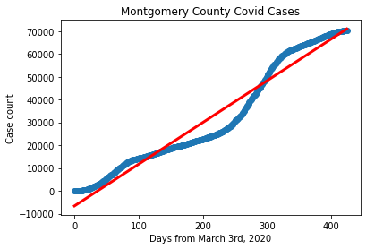

```python
reg = LinearRegression().fit(covid_table['Days from March 3rd, 2020'].to_numpy().reshape(-1,1), covid_table['Montgomery'].to_numpy().reshape(-1,1))
pred = reg.predict(covid_table['Days from March 3rd, 2020'].to_numpy().reshape(-1,1))
plt.scatter(covid_table['Days from March 3rd, 2020'], covid_table['Montgomery'])
plt.plot(covid_table['Days from March 3rd, 2020'], pred, color='red',linewidth=3)
plt.title('Montgomery County Covid Cases')
plt.xlabel('Days from March 3rd, 2020')
plt.ylabel('Case count')
plt.show()
```

We can also visualize the total number of cases of each county by a bar graph thereby looking at the total cases of the latest date.

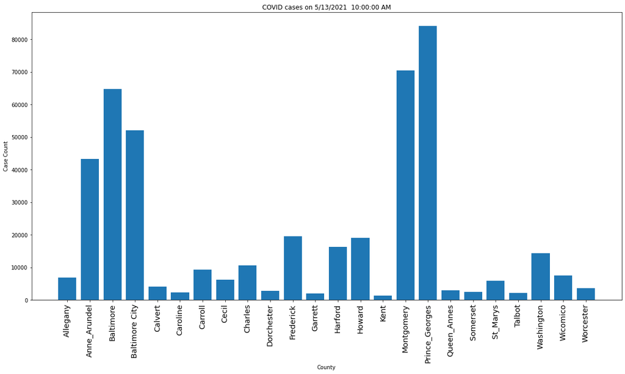

```python
plt.figure(figsize=(20,10))
plt.xticks(rotation='vertical', fontsize='x-large')
plt.bar(latest_cases.keys().tolist(), latest_cases.values)
plt.title('COVID cases on 5/13/2021  10:00:00 AM')
plt.xlabel('County')
plt.ylabel('Case Count')

plt.show()
```

We see that Anne Arundel, Baltimore, Baltimore City, Montgomery, and Prince George counties are locations where there are the most COVID cases. When we analyze our socioeconomic characteristics, we want to compare their trends against this bar plot to observe any correlatio between the characteristic and COVID cases.

##### Education

For education, we want to analyze the different levels of education for each county as that's the primary way to assess the education level of a county. To compare the education levels, I'll plot a group bar chart. We will ignore the other data about the public education system for now.

NOTE: An important pitfall to avoid here is by not considering the population of people in each county. We want to know the ratio of students to population of people per county so we have an accurate measurement of the percentage for each education level. If we don't consider population data and only consider the number of people that has received a certain level of education, then we are not using independent variables.

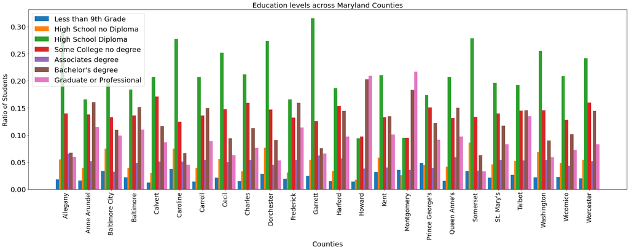

```python
x = np.arange(education.shape[0])
width = 0.15 # width of bars

population_data = population['Total Population']

labels = education['County']
less_than = education['Less than 9th Grade'].divide(other=population_data)
high_school_nop = education['High School no Diploma'].divide(other=population_data)
high_school_yep = education['High School Diploma'].divide(other=population_data)
some_college = education['Some College no degree'].divide(other=population_data)
associates = education['Associates degree'].divide(other=population_data)
bachelor = education['Bachelor\'s degree'].divide(other=population_data)
grad = education['Graduate or Professional'].divide(other=population_data)

fig, ax = plt.subplots(figsize=(25,10))

rect1 = ax.bar(x-width*5/2, less_than, width, label='Less than 9th Grade')
rect2 = ax.bar(x-width*3/2, high_school_nop, width, label='High School no Diploma')
rect3 = ax.bar(x-width, high_school_yep, width, label='High School Diploma')
rect4 = ax.bar(x, some_college, width, label='Some College no degree')
rect5 = ax.bar(x+width, associates, width, label='Associates degree')
rect6 = ax.bar(x+width*3/2, bachelor, width, label='Bachelor\'s degree')
rect7 = ax.bar(x+width*5/2, grad, width, label='Graduate or Professional')

ax.set_ylabel('Ratio of Students', fontsize='xx-large')
ax.set_xlabel('Counties', fontsize=20)
ax.legend(prop={'size':20})
ax.set_xticks(x)
ax.set_xticklabels(labels, rotation='vertical', fontsize='xx-large')
ax.tick_params(axis='y', labelsize=20)
ax.set_title('Education levels across Maryland Counties', fontsize=20)

fig.tight_layout()

plt.show()
```

Let's take the average ratio for each education level and plot a residual plot to see which counties lie above average and which lie below for better analysis on whether there's a pattern with COVID data.

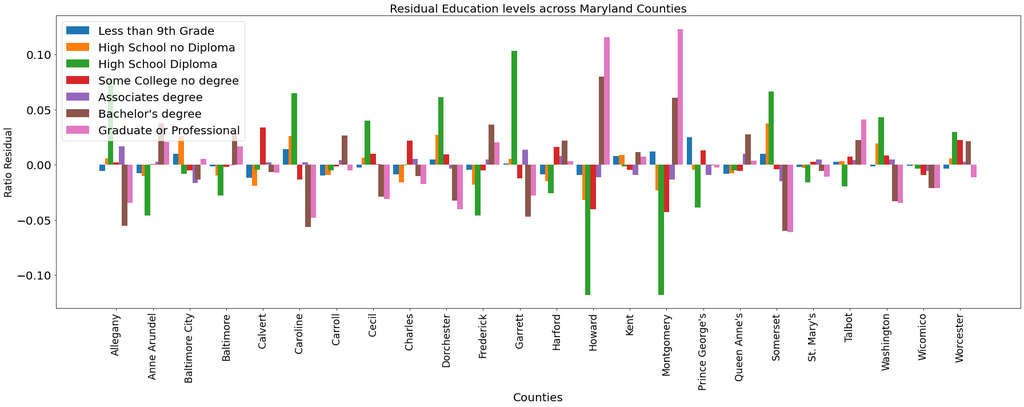

```python
# computing averages
less_than_avg = less_than.mean()
high_nop_avg = high_school_nop.mean()
high_yep_avg = high_school_yep.mean()
some_avg = some_college.mean()
associates_avg = associates.mean()
bachelors_avg = bachelor.mean()
grad_avg = grad.mean()

less_than_mean = less_than-less_than_avg
high_school_nop_mean = high_school_nop-high_nop_avg
high_school_yep_mean = high_school_yep-high_yep_avg
some_college_mean = some_college-some_avg
associates_mean = associates-associates_avg
bachelor_mean = bachelor-bachelors_avg
grad_mean = grad-grad_avg

fig, ax = plt.subplots(figsize=(25,10))

rect1 = ax.bar(x-width*5/2, less_than_mean, width, label='Less than 9th Grade')
rect2 = ax.bar(x-width*3/2, high_school_nop_mean, width, label='High School no Diploma')
rect3 = ax.bar(x-width, high_school_yep_mean, width, label='High School Diploma')
rect4 = ax.bar(x, some_college_mean, width, label='Some College no degree')
rect5 = ax.bar(x+width, associates_mean, width, label='Associates degree')
rect6 = ax.bar(x+width*3/2, bachelor_mean, width, label='Bachelor\'s degree')
rect7 = ax.bar(x+width*5/2, grad_mean, width, label='Graduate or Professional')

ax.set_ylabel('Ratio Residual', fontsize='xx-large')
ax.set_xlabel('Counties', fontsize=20)
ax.legend(prop={'size':20})
ax.set_xticks(x)
ax.set_xticklabels(labels, rotation='vertical', fontsize='xx-large')
ax.tick_params(axis='y', labelsize=20)
ax.set_title('Residual Education levels across Maryland Counties', fontsize=20)

fig.tight_layout()

plt.show()
```

Upon initial observation, most people only get their high school diploma across most counties. Counties with the highest ratio of students with a high school diploma are Allegany, Caroline, Garrett, Dorchester, and Somerset county. Some counties like Howard, Montgomery, and Anne Arundel have a higher than average ratio of people that get their bachelor's degree or graduate's/profession degree.

There's no clear correlation between education level in a county with number of covid cases. The counties with top covid rates (Anne Arundel, Baltimore, Baltimore City, Montgomery, and Prince George) don't have a pattern that differentiates them from other counties in terms of education levels. In fact Prince George and Montgomery County have very different education ratios.

Next we'll consider the public school system infrastructure and analyze the relationship between public school student to teacher ratio against public school expenditure per pupil and then map the expenditure to COVID cases.

```python
temp = pd.DataFrame(education[['Public School Student-Teacher Ratio', 'Public School Expenditures Per Pupil ($ Dollars)']])
temp.sort_values(by='Public School Expenditures Per Pupil ($ Dollars)', axis=0,inplace=True)
```

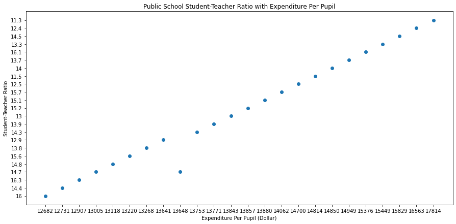

```python
plt.figure(figsize=(15,7))
plt.scatter(temp['Public School Expenditures Per Pupil ($ Dollars)'], temp['Public School Student-Teacher Ratio'])
plt.title('Public School Student-Teacher Ratio with Expenditure Per Pupil')
plt.ylabel('Student-Teacher Ratio')
plt.xlabel('Expenditure Per Pupil (Dollar)')
plt.show()
```

```python
def removeSpecialChar(index):
    if '_' in index:
        names = index.split('_')
        index = " ".join(names)
    if '\'' in index:
        names=index.split('\'')
        index =  "".join(names)
    if '.' in index:
        names=index.split('.')
        index = "".join(names)

    return index
```

```python
expend = education.set_index('County')['Public School Expenditures Per Pupil ($ Dollars)']
expend.rename(index=removeSpecialChar,inplace=True)
latest_cases.rename(index=removeSpecialChar,inplace=True)
temp = pd.concat([expend, latest_cases], axis=1)
temp.sort_values(by='Public School Expenditures Per Pupil ($ Dollars)', axis=0,inplace=True)
```

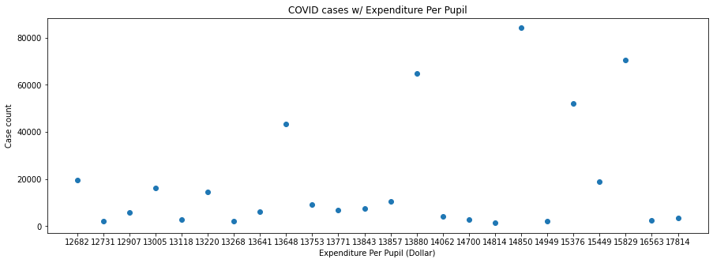

```python
plt.figure(figsize=(15,5))
plt.scatter(temp['Public School Expenditures Per Pupil ($ Dollars)'], temp[424])
plt.title('COVID cases w/ Expenditure Per Pupil')
plt.ylabel('Case count')
plt.xlabel('Expenditure Per Pupil (Dollar)')
plt.show()
```

There's no pattern between the expenditure between expenditure per pupil and covid case count, so the socioeconomic characteristics we observed in education has no correlation with COVID cases. Therefore, it's likely that the education level of a county and the infrastructure of the county on public school system has no effect on the COVID case in that county.

##### Population

We'll observe the age and racial make up of each county in the next step to check for any correlations with the COVID case count. We want to observe the total population per county against covid cases before we start analyzing racial makeup or age distribution of counties to gain a sense of how population affects covid cases as our "control" variable. We won't be overly analyzing this because it's excluded from our hypothesis.

```python
x = np.arange(population.shape[0])
width = 0.15 # width of bars

pop = population.set_index('County')['Total Population']
pop.rename(index=removeSpecialChar,inplace=True)

temp=pd.concat([pop, latest_cases], axis=1)
temp.sort_values(by='Total Population', axis=0,inplace=True)
```

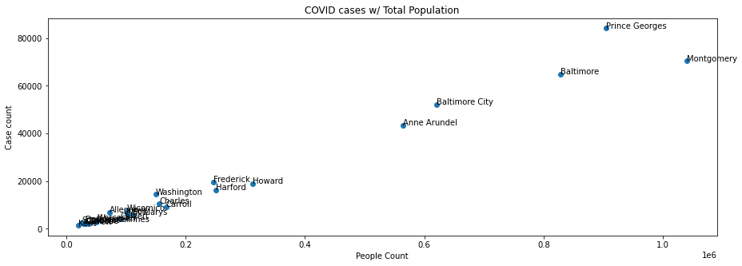

```python
fig, ax = plt.subplots(figsize=(15,5))

plt.scatter(temp['Total Population'], temp[424])
plt.title('COVID cases w/ Total Population')
plt.ylabel('Case count')
plt.xlabel('People Count')

for i, text in enumerate(temp.index.tolist()):
    ax.annotate(text, (temp['Total Population'][i], temp[424][i]))
plt.show()
```

We find a very strong correlation between population count and covid case count. It's practically a linear relationship between the two. We want to keep this in mind when we analyze the ratios for racial groups and age distribution so that we aren't accidentally affecting our independent variable with external factors. Therefore, we should analyze ratios and not population numbers to keep the data independent.

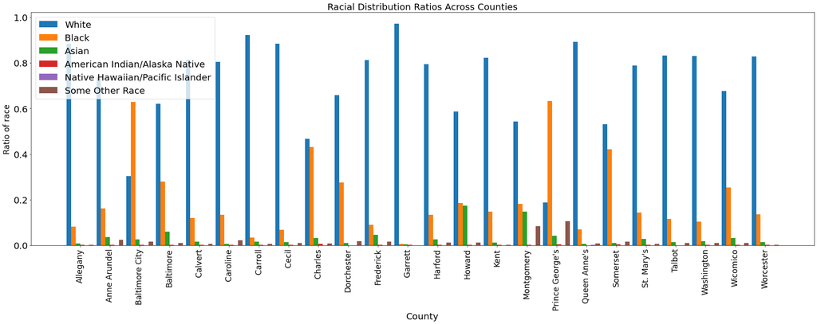

```python
x = np.arange(education.shape[0])
width = 0.15 # width of bars

population_data = population['Total Population']

labels = population['County']

white = population['White Alone'].divide(other=population_data)
black = population['Black Alone'].divide(other=population_data)
asian = population['Asian Alone'].divide(other=population_data)
indian = population['American Indian/Alaska Native Alone'].divide(other=population_data)
native = population['Native Hawaiian/Pacific Islander Alone'].divide(other=population_data)
other = population['Some Other Race Alone'].divide(other=population_data)

fig, ax = plt.subplots(figsize=(25,10))

rect1 = ax.bar(x-width*5/2, white, width, label='White')
rect2 = ax.bar(x-width*3/2, black, width, label='Black')
rect3 = ax.bar(x-width/2, asian, width, label='Asian')
rect4 = ax.bar(x+width/2, indian, width, label='American Indian/Alaska Native')
rect5 = ax.bar(x+width*3/2, native, width, label='Native Hawaiian/Pacific Islander')
rect6 = ax.bar(x+width*5/2, other, width, label='Some Other Race')


ax.set_ylabel('Ratio of race', fontsize='xx-large')
ax.legend(prop={'size':20})
ax.set_xticks(x)
ax.set_xticklabels(labels, rotation='vertical', fontsize='xx-large')
ax.tick_params(axis='y', labelsize=20)
ax.set_title('Racial Distribution Ratios Across Counties', fontsize=20)
ax.set_xlabel('County', fontsize=20)
fig.tight_layout()

plt.show()
```

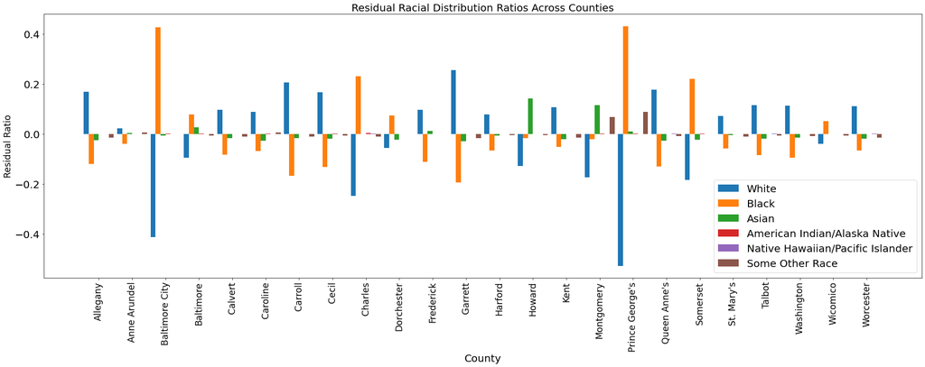

```python
white_mean = white-white.mean()
black_mean = black-black.mean()
asian_mean = asian-asian.mean()
indian_mean = indian-indian.mean()
native_mean = native-native.mean()
other_mean = other-other.mean()

fig, ax = plt.subplots(figsize=(25,10))

rect1 = ax.bar(x-width*5/2, white_mean, width, label='White')
rect2 = ax.bar(x-width*3/2, black_mean, width, label='Black')
rect3 = ax.bar(x-width/2, asian_mean, width, label='Asian')
rect4 = ax.bar(x+width/2, indian_mean, width, label='American Indian/Alaska Native')
rect5 = ax.bar(x+width*3/2, native_mean, width, label='Native Hawaiian/Pacific Islander')
rect6 = ax.bar(x+width*5/2, other_mean, width, label='Some Other Race')


ax.set_ylabel('Residual Ratio', fontsize='xx-large')
ax.legend(prop={'size':20})
ax.set_xticks(x)
ax.set_xticklabels(labels, rotation='vertical', fontsize='xx-large')
ax.tick_params(axis='y', labelsize=20)
ax.set_title('Residual Racial Distribution Ratios Across Counties', fontsize=20)
ax.set_xlabel('County', fontsize=20)
fig.tight_layout()

plt.show()
```

Let's pull up our list of covid cases to compare the number of cases with racial distribution.

```python
latest_cases = covid_table.iloc[covid_table.shape[0]-1][:-1]
latest_cases.nlargest(10)
```

```
Prince_Georges    84149.0
Montgomery        70394.0
Baltimore         64807.0
Baltimore City    52153.0
Anne_Arundel      43301.0
Frederick         19614.0
Howard            19067.0
Harford           16349.0
Washington        14413.0
Charles           10698.0
Name: 424, dtype: float64
```

It's also worth to note that there are 7/24 counties that have a significant positive black population ratio residual. Out of the 7, 4 of the counties are listed as top 10 highest case counties. If we apply a little bit of statistics, about 30% of counties are have a higher than average black ratio, and about 40% of the top 10 counties have a higher than average black ratio and if we only look at the top 5 counties then 60% of the top counties have above average black ratio.

This correlation raises some eyebrows as to whether there's enough evidence to suggest a correlation between racial disparity and covid rates.

### Too Much Data!

Unfortuntely, there's just too much data we have on our hands. We could spend an enormous amount of time trying to connect each socioeconomic factor with COVID cases in each county, but that's very time consuming and requires a lot of computational resources. With enough time and resources however, we can dive deeper into the analysis part of this tutorial to observe the relationships between socioeconomic characteristics and county infrastructure, but as of right now that resource is not avaiable.

An essential part of data analysis is being able to go back to previous steps of data processing to clear out the data we need and don't need and format the data in such a way that's useful for us to analyze. When I realize I have too much data here, I need to go back to data processing step and drop a lot of the unnecessary data. In this case, we would have to drop all the other columns regarding transportation infrastructure, quality of life, household income, employment rates, etc. to conserve our efforts into focusing on whether there's correlation between covid cases and racial makeup and education levels.

Therefore, we will stop our analysis here and move on to concluding our hypothesis.

#### Hypothesis Testing

We've seen that education levels don't formulate a pattern between counties; there's no significant pattern we can observe from the average education levels in each county that would correlate to the rise of covid cases.

However, with racial ratios between counties, we do see a pattern where counties with a higher than average black population suffers more from COVID cases than other counties. 3 of the 5 top 5 counties with highest number of cases were counties with above average black population ratio while only 7 out of 24 of those counties has an above average black population. Therefore, we do have reason to suspect that racial disparity is a socioeconomic characteristic that affects the number of COVID cases disapproportionately.

Therefore, we reject our null hypothesis and say there are socioeconomic characteristics that affect COVID rates other than population in that county.

### Conclusion

When determining which counties would be most affected by a pandemic, we should not be looking at the education levels in that area. Rather, we should be observing the racial disparity between counties and see that counties with above average black population ratio should receive more care.

In the data analysis/hypothesis testing phase, we choose only two economic characteristics and one county infrastructure to observe. These characteristics were chosen purely because we have a list of characteristics to choose from and they had the most complete set of data that was needed to analyze the correlation between groups of data against COVID cases.

This data science pipeline takes you through the process of:

1. Data Collection
2. Data Processing
3. Hypothesis formulation
4. Data Analysis
5. Hypothesis testing There's no machine learning(ML) component involved with this process because there's so many other socioeconomic characters we have yet to explore and it's unfair to learn a model to fit our socioeconomic characteristics when we haven't explored most of them yet.

I hope this pipeline taught you the process of collecting and using data to find relationships but also teaches you about flexibility in data processing and data analysis. It's important to know that when something doesn't work out in the pipeline we could always go back to fix it and then reevaluate our progress.

To learn more about cleaning up your data and dealing with missing data:

[Data Cleaning](https://www.tableau.com/learn/articles/what-is-data-cleaning)

[sklearn's imputation of missing vlaues](https://scikit-learn.org/stable/modules/impute.html)

Check out more of the US government's datasets [here](https://www.data.gov/)